# Logistic Regression

March 22, 2018

## Why do we need this?

Load the hypothetical gre data from ucla dataset, and explore the data (summary).

(note: `xtabs` vs `count()`)

Say we want to predict whether someone is admitted to grad school… what could we do?

Q: What percent of the students were admitted to grad school?

## What kind of function (board work)

## Doing logistic regression with the grad school dataset

The `lm` command did linear regression, the `glm` command is the generalized linear model.

Format:

`model <- glm(y ~ x, data = mydata, family = "binomial")`

Why binomial?

## More models

Make a logistic model predicting admit from gre. Then make a second model predicting admit from gpa.

Write down both equations in both the logit form and the probability form.

## The 50% mark

How can we figure out when we hit the 50% mark?

## New variable

Make a new column called `prestige` which is 1 if the school has rank 1 or 2, and 0 if it has rank 3 or 4.

Make a new logistic model predicting admit using `prestige`.

```r
binary <- binary %>% mutate(prestige = as.numeric((rank==1) | (rank==2)))
```

## Odds Ratios

```r
binary %>% count(admit, prestige)
```

```
## # A tibble: 4 x 3
##   admit prestige     n
##   <int>    <dbl> <int>
## 1     0       0.   148
## 2     0       1.   125
## 3     1       0.    40
## 4     1       1.    87
```

(same as)

```r
binary %>% group_by(admit, prestige) %>% summarize(n = n())
```

## Odds Ratios

```r
binary %>% count(admit, prestige)
```

```
## # A tibble: 4 x 3
##   admit prestige     n
##   <int>    <dbl> <int>
## 1     0       0.   148
## 2     0       1.   125
## 3     1       0.    40
## 4     1       1.    87
```

What are the odds of being admitted if you’re not in a prestigious school? What are the odds of being admitted if you are in a prestigious school?

The *odds ratio* is the ratio of those two values. How do we interpret it?

## Empirical logit

\[\textrm{Empirical logit} = \textrm{logit}(\hat{p}) = \log\left(\frac{\hat{p}}{1-\hat{p}}\right) = \log \left( \frac{\# yes}{\# no} \right)\]

## Logit as slope

Suppose prestige is predicting log odds of being admitted (what kind of function?). What is the slope?

## Slope is the log of the odds ratio.

Therefore, the odds ratio is exp(fitted slope).

## Coding this

```r
binmodel <- binary %>% glm(admit~prestige, family="binomial", data=.)
binmodel$coefficients
```

```
## (Intercept)    prestige
##  -1.3083328   0.9459272
```

```r
exp(binmodel$coefficients)
```

```
## (Intercept)    prestige
##   0.2702703   2.5752000
```

## Same Data

Rerun logistic regression - predict admit based on gpa. Exponentiate your slope - how do you interpret this value?

## Plotting GRE

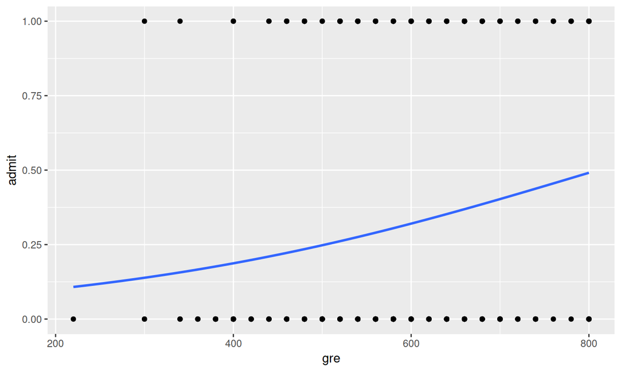

```r
binary %>%
  ggplot(aes(x = gre, y = admit)) +
  geom_point() +
  geom_smooth(method="glm", method.args = list(family = "binomial"), se=FALSE)
```

## Plotting GPA

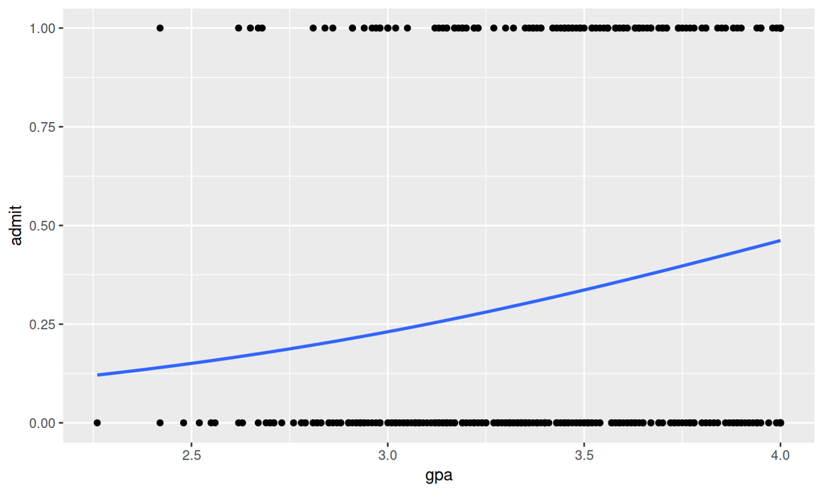

```r
binary %>%
  ggplot(aes(x = gpa, y = admit)) +
  geom_point() +
  geom_smooth(method="glm", method.args = list(family = "binomial"), se=FALSE)
```

## Titanic data (titanic package)

```r
require(titanic)
d <- titanic_train
```

Predict survival probability from age.

## Results

```r
model1 <- d %>% glm(Survived~Age, family="binomial", data=.)
summary(model1)
```

```
##
## Call:
## glm(formula = Survived ~ Age, family = "binomial", data = .)
##
## Deviance Residuals:
##     Min       1Q   Median       3Q      Max
## -1.1488  -1.0361  -0.9544   1.3159   1.5908
##
## Coefficients:
##             Estimate Std. Error z value Pr(>|z|)
## (Intercept) -0.05672    0.17358  -0.327   0.7438
## Age         -0.01096    0.00533  -2.057   0.0397 *
## ---
## Signif. codes:  0 '***' 0.001 '**' 0.01 '*' 0.05 '.' 0.1 ' ' 1
##
## (Dispersion parameter for binomial family taken to be 1)
##
##     Null deviance: 964.52  on 713  degrees of freedom
## Residual deviance: 960.23  on 712  degrees of freedom
##   (177 observations deleted due to missingness)
## AIC: 964.23
##
## Number of Fisher Scoring iterations: 4
```

## Predicted results

```r
predict(model1, d, type="response")
```

[output not shown]

[output cut: 201 more lines]

[output not shown]

```r
d$predicted <- predict(model1, d, type="response")
```

## More predictions

```r
predict(model1, data.frame(Age=25), type="response")
```

```
##         1
## 0.4180436
```

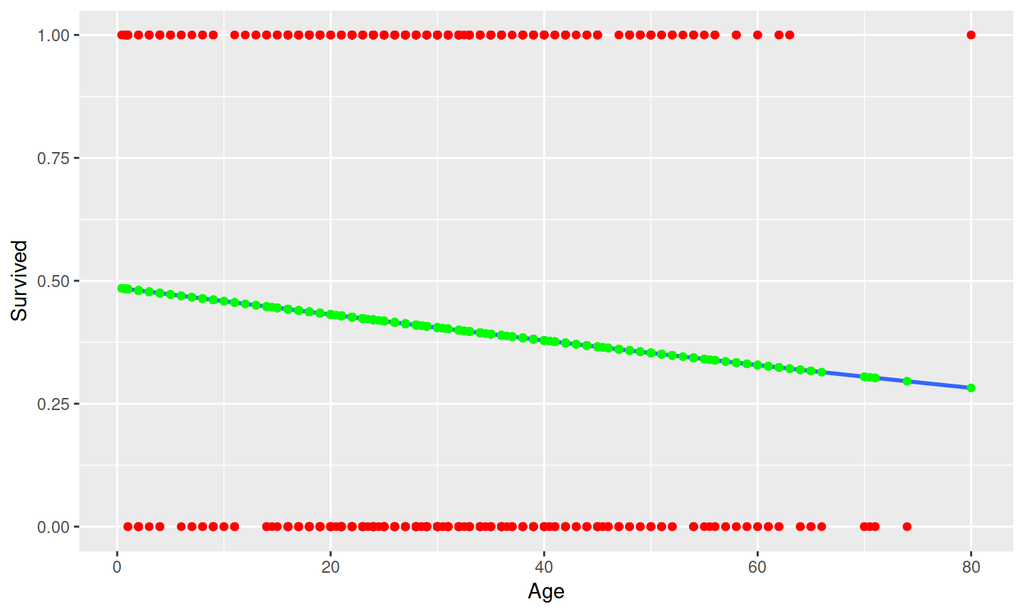

```r
d %>%
  ggplot(aes(x=Age, y=Survived))+
  geom_point(color="red")+
  geom_smooth(method="glm", method.args = list(family = "binomial"), se=FALSE)+
  geom_point(color="green", aes(x=Age, y=predicted))
```

## What is the following going to do?

```r
d %>%
  ggplot(aes(x=Age, y=Survived, colour=factor(Pclass)))+
  geom_point()+
  geom_smooth(method="glm", method.args = list(family = "binomial"), se=FALSE)+
  geom_point(aes(x=Age, y=predicted))
```

## The augment function

```r
model1 <- d %>% glm(Survived~Age, family="binomial", data=.)
```

```r
require(broom)
model1 %>% augment(type.predict="response")
```

```
##     .rownames Survived   Age   .fitted    .se.fit     .resid        .hat
## 1           1        0 22.00 0.4260661 0.02093692 -1.0537942 0.001792614
## 2           2        1 38.00 0.3838272 0.02118204  1.3838806 0.001897132
## 3           3        1 26.00 0.4153788 0.01902820  1.3255674 0.001490997
## 4           4        1 35.00 0.3916351 0.01962422  1.3692515 0.001616363
## 5           5        0 35.00 0.3916351 0.01962422 -0.9969758 0.001616363
## 6           7        0 54.00 0.3432713 0.03437987 -0.9170433 0.005243063
## 7           8        0  2.00 0.4803475 0.04095580 -1.1441984 0.006719893
## 8           9        1 27.00 0.4127189 0.01875005  1.3304049 0.001450455
## 9          10        1 14.00 0.4476397 0.02757759  1.2678854 0.003075824
## 10         11        1  4.00 0.4748768 0.03858327  1.2204096 0.005969745
## 11         12        1 58.00 0.3334541 0.03807055  1.4820595 0.006520970
## 12         13        0 20.00 0.4314365 0.02230345 -1.0626780 0.002027908
## 13         14        0 39.00 0.3812377 0.02180941 -0.9798306 0.002016360
## 14         15        0 14.00 0.4476397 0.02757759 -1.0895455 0.003075824
```

[output cut: 1415 more lines]

```r
newmodel1 <-
model1 %>% augment(type.predict = "response") %>%
  mutate(Survived_hat = round(.fitted))
```

```r
newmodel1 %>%
  select(Survived, Survived_hat) %>%
  table()
```

```
##         Survived_hat
## Survived   0
##        0 424
##        1 290
```

## Assessing Fit (9.3)

- Linearity
  - Check with a plot
- Randomness
  - Think about data
- Independence
  - Think about data

## Linearity

- What should be linear?
- How should we check it?

## What do we do if we don’t have linearity?

## Multiple logistic regression

How do we think this is going to work?

## The Portugese banking dataset

```r
bank_full <- read_delim("../data/bankfull.csv", ";", escape_double = FALSE, trim_ws = TRUE)
bank_full$y <- as.numeric(as.factor(bank_full$y))-1
```

## GLM

```r
bank_full %>% glm(y~age, family="binomial", data=.) %>% summary()
```

```
##
## Call:
## glm(formula = y ~ age, family = "binomial", data = .)
##
## Deviance Residuals:
##     Min       1Q   Median       3Q      Max
## -0.5975  -0.5087  -0.4917  -0.4817   2.1427
##
## Coefficients:
##              Estimate Std. Error z value Pr(>|z|)
## (Intercept) -2.319506   0.058083 -39.934  < 2e-16 ***
## age          0.007229   0.001352   5.346 8.98e-08 ***
## ---
## Signif. codes:  0 '***' 0.001 '**' 0.01 '*' 0.05 '.' 0.1 ' ' 1
##
## (Dispersion parameter for binomial family taken to be 1)
##
##     Null deviance: 32631  on 45210  degrees of freedom
## Residual deviance: 32603  on 45209  degrees of freedom
## AIC: 32607
##
## Number of Fisher Scoring iterations: 4
```

## GLM2

```r
bank_full %>% glm(y~balance, family="binomial", data=.) %>% summary()
```

```
##
## Call:
## glm(formula = y ~ balance, family = "binomial", data = .)
##
## Deviance Residuals:
##     Min       1Q   Median       3Q      Max
## -2.0459  -0.4955  -0.4877  -0.4850   2.1480
##
## Coefficients:
##               Estimate Std. Error z value Pr(>|z|)
## (Intercept) -2.081e+00  1.595e-02 -130.50   <2e-16 ***
## balance      3.958e-05  3.840e-06   10.31   <2e-16 ***
## ---
## Signif. codes:  0 '***' 0.001 '**' 0.01 '*' 0.05 '.' 0.1 ' ' 1
##
## (Dispersion parameter for binomial family taken to be 1)
##
##     Null deviance: 32631  on 45210  degrees of freedom
## Residual deviance: 32532  on 45209  degrees of freedom
## AIC: 32536
##
## Number of Fisher Scoring iterations: 4
```

## GLM3

```r
bank_full %>% glm(y~age+balance, family="binomial", data=.) %>% summary()
```

```
##
## Call:
## glm(formula = y ~ age + balance, family = "binomial", data = .)
##
## Deviance Residuals:
##     Min       1Q   Median       3Q      Max
## -1.9950  -0.5037  -0.4869  -0.4745   2.1539
##
## Coefficients:
##               Estimate Std. Error z value Pr(>|z|)
## (Intercept) -2.323e+00  5.810e-02 -39.984  < 2e-16 ***
## age          5.938e-03  1.361e-03   4.364 1.28e-05 ***
## balance      3.783e-05  3.866e-06   9.786  < 2e-16 ***
## ---
## Signif. codes:  0 '***' 0.001 '**' 0.01 '*' 0.05 '.' 0.1 ' ' 1
##
## (Dispersion parameter for binomial family taken to be 1)
##
##     Null deviance: 32631  on 45210  degrees of freedom
## Residual deviance: 32513  on 45208  degrees of freedom
## AIC: 32519
##
## Number of Fisher Scoring iterations: 4
```

## Interpreting the multivariate logistic regression

How do we interpret the coefficients?

## Inference with logistic regression (9.4)

What was inference like in the linear regression setting?

## Tools we had

- t-test (confidence intervals)
- ANOVA (F-test)
- SSModel vs SSE
- \(R^2\)
- \(\hat{\sigma}_\epsilon\)

## New tools

- Confidence interals (and p-value, z-test, Wald statistic)
  - What is the null hypothesis?
- Minimize Deviance (\(=-2*\ln(L)\)), this is like the F-test (ANOVA)
  - Test is based on the change in deviance between null and tested model
  - Change is approximately a \(\Chi^2\)-distribution, with df the number of parameters
    - Called a likelihood ratio test (let’s do this by hand)

## LR Test

Testing the null hypothesis that the slope is 0.

\(G = -2 \ln(L_0) - (-2 \ln(L))\)

Why are we calling this a ratio?

## To do the LR test

```r
require(lmtest)
mod1 <- bank_full %>% glm(y~1, family="binomial", data=.)
mod2 <- bank_full %>% glm(y~age, family="binomial", data=.)
lrtest(mod1,mod2)
```

```
## Likelihood ratio test
##
## Model 1: y ~ 1
## Model 2: y ~ age
##   #Df LogLik Df  Chisq Pr(>Chisq)
## 1   1 -16316
## 2   2 -16301  1 28.236  1.074e-07 ***
## ---
## Signif. codes:  0 '***' 0.001 '**' 0.01 '*' 0.05 '.' 0.1 ' ' 1
```

## LRTest

```r
require(lmtest)
mod1 <- bank_full %>% glm(y~1, family="binomial", data=.)
mod2 <- bank_full %>% glm(y~age, family="binomial", data=.)
mod3 <- bank_full %>% glm(y~age+balance, family="binomial", data=.)
lrtest(mod2,mod3)
```

```
## Likelihood ratio test
##
## Model 1: y ~ age
## Model 2: y ~ age + balance
##   #Df LogLik Df  Chisq Pr(>Chisq)
## 1   2 -16301
## 2   3 -16256  1 89.995  < 2.2e-16 ***
## ---
## Signif. codes:  0 '***' 0.001 '**' 0.01 '*' 0.05 '.' 0.1 ' ' 1
```

## More LRTest

```r
require(lmtest)
mod1 <- bank_full %>% glm(y~1, family="binomial", data=.)
mod2 <- bank_full %>% glm(y~age, family="binomial", data=.)
mod3 <- bank_full %>% glm(y~age+balance, family="binomial", data=.)
lrtest(mod1,mod3)
```

```
## Likelihood ratio test
##
## Model 1: y ~ 1
## Model 2: y ~ age + balance
##   #Df LogLik Df  Chisq Pr(>Chisq)
## 1   1 -16316
## 2   3 -16256  2 118.23  < 2.2e-16 ***
## ---
## Signif. codes:  0 '***' 0.001 '**' 0.01 '*' 0.05 '.' 0.1 ' ' 1
```

## Wald vs LRTest

- These won’t always agree
- LR test is the better measure when they don’t agree
  - LR test needs to test nested models (otherwise, you can use the AIC)

## Question

Would adding an interaction term to the model predicting \(y\) using age and balance significantly improve the model? Use both the Wald statistic (z) and a likelihood ratio test to determine the answer.

## The Full Dataset

Consider the entire dataset. What is the best model for predicting \(y\)?

Note:

```r
summary(glm(y~., data=bank_full, family="binomial"))
```

## Another aside

```r
step(glm(y~., data=bank_full, family="binomial"))
```

## Likelihood Functions (11.1)

- Probabilities: \(P(A|B)\)
- Logistic probabilities: \(P(X=1 | \beta_0, \beta_1, ...)\) or \(P(data \ | \ parameters)\)
- Likelihood: \(P(parameters \ | \ data)\)

## Example

Imagine you have a spinner. Pick the probability. What are the chances of getting Y? N?

What are the chances of getting NN? YN? NY? YY? YNY?

How do we draw this?

## How do we make sense of this is more dimensions?

## Relating this back to facebook…